# Composiciones de Tallas D. trunculus

Datos Monitoreo poblacional FEMP_AND_04

Mardones, M; Delgado, M

05 April, 2024

```r
rm(list = ls())
knitr::opts_chunk$set(echo = TRUE,
                      message = FALSE,
                      warning = FALSE,
                      fig.align = 'center',
                      dev = 'jpeg',
                      dpi = 300,
                      fig.align='center')
#XQuartz is a mess, put this in your onload to default to cairo instead
options(bitmapType = "cairo")
# (https://github.com/tidyverse/ggplot2/issues/2655)
# Lo mapas se hacen mas rapido
```

```r
library(tidyverse)
library(ggridges)
library(readxl)
library(here)
library(lubridate)
library(readr)
library(ggthemes)
library(hrbrthemes)
library(kableExtra)
library(gtsummary)
```

# Contexto de las composiciones de tallas del monitoreo

El monitoreo de tallas considera dos compenentes. muestreo espacial, temporal y por arte de pesca (comercial y poblacional)

# Metodología de manipulación de data

Leer y juntar Data Base provenientos de todos los muestreos, que datan desde el 2013.

Cabe señalar que las bases de datos previas al 2020, tiene (o pueden contener) otras columnas como densidad, rendimiento y tallas.

Ordenar la data. El año 2013 es el que tiene mas diferencias de formatos. Tambien debo hacer columnas con formato de los datos posteriores al 2020. Para esto se diagnosticaron las bases del año 2013 que estaban separadas por rastro y por mes con diferentes formatos de campos. Por ello se realiza un trabajo de data handling.

## Datos 2013

```r
# Enero
sizep01_13 <-read_excel("Data/Datos_13_14/Datos tallas 2013/Muestreo poblacional 22_1_14.xls",
    sheet = "Coquina") %>%
  mutate(
    Beach = NA,
    Sampling.point = NA,
    rastro="POBLACIONAL",
    CAT=NA,
    Categoria=NA,
    size=NA,
    ID_codificado_muestreo=NA
    ) %>%
  rename(sizeE=`Peso Submuestra`) %>%
  select(-c(1, 3, 4, 5, 6))
sizep01_13$Date <- ymd("2013-01-01")

# Marzo
sizec03_13 <- read_excel("Data/Datos_13_14/Datos tallas 2013/Coquina 26_03_2013_Luis.xlsx",
    sheet = "Comercial",
    skip = 2)%>%
  select(2) %>%
  mutate(
    Beach = NA,
    Sampling.point = NA,
    rastro="COMERCIAL",
    CAT=NA,
    Categoria=NA,
    size=NA,
    ID_codificado_muestreo=NA
    ) %>%
  rename(sizeE=Largo)
sizec03_13$Date <- ymd("2013-03-01")

# mayo
sizep05_13 <- read_excel("Data/Datos_13_14/Datos tallas 2013/Muestro_Mayo_2.xlsx",
    sheet = "Poblacion") %>%
  mutate(
    Beach = NA,
    Sampling.point = NA,
    rastro="POBLACIONAL",
    CAT=NA,
    Categoria=NA,
    size=NA,
    ID_codificado_muestreo=NA
    ) %>%
  dplyr::rename(sizeE=Dato)%>%
  select(-c(2, 3, 4))
sizep05_13$Date <- ymd("2013-05-01")



sizec05_13 <- read_excel("Data/Datos_13_14/Datos tallas 2013/Muestro_Mayo_2.xlsx",
    sheet = "Comercial") %>%
  mutate(
    Beach = NA,
    Sampling.point = NA,
    rastro="COMERCIAL",
    CAT=NA,
    Categoria=NA,
    size=NA,
    ID_codificado_muestreo=NA
    ) %>%
  dplyr::rename(sizeE=...1)%>%
  select(-c(2, 3, 4, 5, 6 , 7))
sizec05_13$Date <- ymd("2013-05-01")

# marzo abril mayo junio nov
sizep2013 <- read_excel(here("Data",
                           "Datos_13_14",
                           "Datos tallas 2014_2015",
                           "DATOS 2013",
                           "Datos tallas_2013.xlsx"),
                       sheet = "Datos poblacional",
                       skip=2)
sizep2013 <- sizep2013 %>%
  select(c(3, 4)) %>%
  mutate(
    Beach = NA,
    Sampling.point = NA,
    rastro="POBLACIONAL",
    CAT=NA,
    Categoria=NA,
    size=NA,
    ID_codificado_muestreo=NA
    ) %>%
  dplyr::rename(sizeE=`Longitud (mm)`,
                Date=Fecha)

# marzo abril jun agost sept oct nov dic
sizec2013 <- read_excel(here("Data",
                           "Datos_13_14",
                           "Datos tallas 2014_2015",
                           "DATOS 2013",
                           "Datos tallas_2013.xlsx"),
                       sheet = "Datos comercial",
                       skip=1)
sizec2013 <- sizec2013 %>%
  select(c(3, 4)) %>%
  mutate(
    Beach = NA,
    Sampling.point = NA,
    rastro="COMERCIAL",
    CAT=NA,
    Categoria=NA,
    size=NA,
    ID_codificado_muestreo=NA
    ) %>%
  dplyr::rename(sizeE=`Longitud (mm)`,
                Date=Fecha)


# Septiembre
sizep09_13 <- read_excel("Data/Datos_13_14/Datos tallas 2013/Muestreo Septiembre coquina-comercial.xlsx",
    sheet = "Sin cribar")

sizep09_13 <- sizep09_13 %>%
  select(c(1)) %>%
  mutate(
    Beach = NA,
    Sampling.point = NA,
    rastro="POBLACIONAL",
    CAT=NA,
    Categoria=NA,
    size=NA,
    ID_codificado_muestreo=NA
    ) %>%
  dplyr::rename(sizeE=Talla)
sizep09_13$Date <- ymd("2013-09-01")

# Octubre
sizep10_13 <- read_excel("Data/Datos_13_14/Datos repetidos dudas/Muestreo octubre coquina_comercial.xlsx",
                         sheet = "Sin cribar")


sizep10_13 <- sizep10_13 %>%
  select(c(1)) %>%
  mutate(
    Beach = NA,
    Sampling.point = 4,
    rastro="POBLACIONAL",
    CAT=NA,
    Categoria=NA,
    size=NA,
    ID_codificado_muestreo=NA
    ) %>%
  dplyr::rename(sizeE=Length)
sizep10_13$Date <- ymd("2013-10-01")


# Diciembre
sizep12_13 <- read_excel("Data/Datos_13_14/Datos tallas 2013/2013_12_23 Coquina (poblacion).xls",
                        skip = 2)
sizep12_13 <- sizep12_13 %>%
  select(c(3)) %>%
  mutate(
    Beach = NA,
    Sampling.point = 2,
    rastro="POBLACIONAL",
    CAT=NA,
    Categoria=NA,
    size=NA,
    ID_codificado_muestreo=NA
    ) %>%
  dplyr::rename(sizeE=talla)
sizep12_13$Date <- ymd("2013-12-01")


sizec12_13 <- read_excel("Data/Datos_13_14/Datos tallas 2013/Muestreo diciembre coquina_comercial.xlsx",
    sheet = "Cribada")
sizec12_13 <- sizec12_13 %>%
  select(c(1)) %>%
  mutate(
    Beach = NA,
    Sampling.point = NA,
    rastro="COMERCIAL",
    CAT=NA,
    Categoria=NA,
    size=NA,
    ID_codificado_muestreo=NA
    ) %>%
  dplyr::rename(sizeE=`COMERCIAL-CRIBADA`)
sizec12_13$Date <- ymd("2013-12-01")
```

Corroboro nombres de los df y junto los datos del 2013

```r
names(sizep01_13) # enero
```

```
## [1] "sizeE"                  "Beach"                  "Sampling.point"
## [4] "rastro"                 "CAT"                    "Categoria"
## [7] "size"                   "ID_codificado_muestreo" "Date"
```

```r
names(sizec03_13) # marzo
```

```
## [1] "sizeE"                  "Beach"                  "Sampling.point"
## [4] "rastro"                 "CAT"                    "Categoria"
## [7] "size"                   "ID_codificado_muestreo" "Date"
```

```r
names(sizec05_13) # mayo
```

```
## [1] "sizeE"                  "Beach"                  "Sampling.point"
## [4] "rastro"                 "CAT"                    "Categoria"
## [7] "size"                   "ID_codificado_muestreo" "Date"
```

```r
names(sizep09_13)# sep
```

```
## [1] "sizeE"                  "Beach"                  "Sampling.point"
## [4] "rastro"                 "CAT"                    "Categoria"
## [7] "size"                   "ID_codificado_muestreo" "Date"
```

```r
names(sizep10_13) # oct
```

```
## [1] "sizeE"                  "Beach"                  "Sampling.point"
## [4] "rastro"                 "CAT"                    "Categoria"
## [7] "size"                   "ID_codificado_muestreo" "Date"
```

```r
names(sizep12_13) # dic
```

```
## [1] "sizeE"                  "Beach"                  "Sampling.point"
## [4] "rastro"                 "CAT"                    "Categoria"
## [7] "size"                   "ID_codificado_muestreo" "Date"
```

```r
names(sizec2013) # comercial hartos meses
```

```
## [1] "Date"                   "sizeE"                  "Beach"
## [4] "Sampling.point"         "rastro"                 "CAT"
## [7] "Categoria"              "size"                   "ID_codificado_muestreo"
```

```r
names(sizep2013) # poblacional hartos meses
```

```
## [1] "Date"                   "sizeE"                  "Beach"
## [4] "Sampling.point"         "rastro"                 "CAT"
## [7] "Categoria"              "size"                   "ID_codificado_muestreo"
```

```r
names(sizec12_13) # dic comercial
```

```
## [1] "sizeE"                  "Beach"                  "Sampling.point"
## [4] "rastro"                 "CAT"                    "Categoria"
## [7] "size"                   "ID_codificado_muestreo" "Date"
```

```r
names(sizep01_13) #enero
```

```
## [1] "sizeE"                  "Beach"                  "Sampling.point"
## [4] "rastro"                 "CAT"                    "Categoria"
## [7] "size"                   "ID_codificado_muestreo" "Date"
```

```r
size2013 <- bind_rows(sizep01_13,
                  sizec03_13,
                  sizec05_13,
                  sizep09_13,
                  sizep10_13,
                  sizep12_13,
                  sizec2013,
                  sizep2013,
                  sizec12_13,
                  sizep01_13) %>%
  mutate(
    DIA = day(Date),
    MES = month(Date),
    ANO = year(Date)
  )
```

Primer vistazo

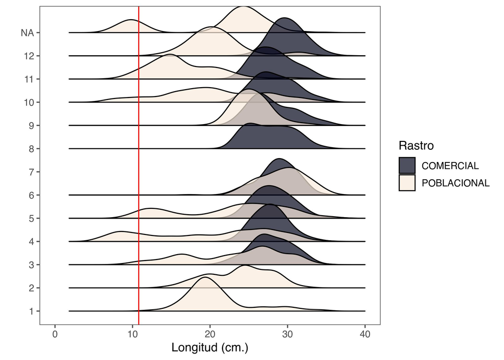

```r
s2013 <- ggplot(size2013 %>%
                  drop_na(sizeE),
               aes(x=sizeE,
                   y = as.factor(MES),
                  fill= as.factor(rastro)))+
  geom_density_ridges2(stat = "density_ridges",
                       position = "points_sina",
                      scale = 1.5,
                      alpha=0.7)+
  # geom_density_ridges2(stat = "binline",
  #                      position = "points_sina",
  #                     scale = 1.5,
  #                     alpha=0.7)+
  #facet_wrap(.~rastro, ncol=4) +
  geom_vline(xintercept = 10.8, color = "red")+
  scale_fill_viridis_d(option="F",
                       name="Rastro")+
  theme(axis.text.x = element_text(angle = 90, hjust = 1))+
  theme_few()+
  xlab("Longitud (cm.)")+
  ylab("")+
  xlim(0,40)
#scale_x_discrete((limits = rev(levels(talla2021$ANO_ARR))))+
s2013
```

## Datos 2014-2015

Estos datos fueron compilados en dos archivos. Estos datos estan agrupados como frecuencias lo que dificulta su trabajo analitico, poor lo cual los desagregamos y dejamos como data crudo.

Junto a ello, cambiamos el formato de las coliummnas siguiendo la logica del os datos del 2013.

```r
sizec14_15 <- read_excel("Data/Datos_13_14/Datos tallas 2014_2015/Datos totales/TALLAS_Com_2014-2015.xlsx") %>%
  select(c(1, 2, 3, 6, 7)) %>%
  mutate(Number2 =round(Number), 0) %>%
  uncount(Number2) %>%
  select(-c(5,6))

sizec14_15 <- sizec14_15 %>%
  mutate(
    rastro="COMERCIAL",
    CAT=NA,
    Categoria=NA,
    size=NA,
    ID_codificado_muestreo=NA
    ) %>%
 rename(Sampling.point = "Station" ,
                sizeE="Size")




sizep14_15 <- read_excel("Data/Datos_13_14/Datos tallas 2014_2015/Datos totales/TALLAS_Pobl_2014-2015.xlsx") %>%
  select(c(1, 2, 3, 6, 7)) %>%
  drop_na(Number) %>%
  mutate(Number2 =round(Number), 0) %>%
  uncount(Number2) %>%
  select(-c(5,6))

sizep14_15 <- sizep14_15 %>%
  mutate(
    rastro="POBLACIONAL",
    CAT=NA,
    Categoria=NA,
    size=NA,
    ID_codificado_muestreo=NA
    ) %>%
 rename(Sampling.point = "Station" ,
                sizeE="Size")
```

Junto los artes de pesca y separo las fechas

```r
size14_15 <- bind_rows(sizec14_15,
                       sizep14_15) %>%
  mutate(
    DIA = day(Date),
    MES = month(Date),
    ANO = year(Date)
  )
```

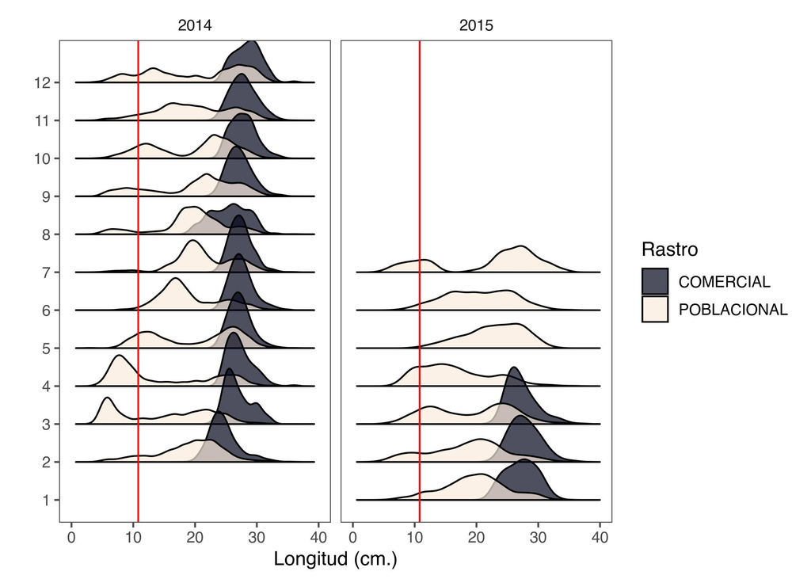

```r
s201415 <- ggplot(size14_15 %>%
                  drop_na(sizeE),
               aes(x=sizeE,
                   y = as.factor(MES),
                  fill= as.factor(rastro)))+
  geom_density_ridges2(stat = "density_ridges",
                       position = "points_sina",
                      scale = 1.5,
                      alpha=0.7)+
  # geom_density_ridges2(stat = "binline",
  #                      position = "points_sina",
  #                     scale = 1.5,
  #                     alpha=0.7)+
  facet_wrap(ANO~., ncol=4) +
  geom_vline(xintercept = 10.8, color = "red")+
  scale_fill_viridis_d(option="F",
                       name="Rastro")+
  theme(axis.text.x = element_text(angle = 90, hjust = 1))+
  theme_few()+
  xlab("Longitud (cm.)")+
  ylab("")+
  xlim(0,40)
#scale_x_discrete((limits = rev(levels(talla2021$ANO_ARR))))+
s201415
```

Separo las fechas

## Datos 2016

solo tengo datos del mes de agosto y sin punto de referencia

```r
# comercial
sizec2016 <- read_excel(here("Data",
                             "Datos_13_14",
                             "Datos tallas 2016",
                             "Muestreo coquina Doคana 23_08_2016.xls"),
                             sheet = "Comercial",
                             skip = 3) %>%
  mutate(
    Beach = NA,
    Sampling.point = NA,
    rastro="COMERCIAL",
    CAT=NA,
    Categoria=NA,
    size=NA,
    ID_codificado_muestreo=NA
    ) %>%
  dplyr::rename(sizeE=Talla)
sizec2016$Date <- ymd("2016-08-01")
#poblacional
sizep2016 <- read_excel(here("Data",
                             "Datos_13_14",
                             "Datos tallas 2016",
                             "Muestreo coquina Doคana 23_08_2016.xls"),
                             sheet = "Poblacional",
                             skip = 3)
df1 <- sizep2016 %>%
  select(1)
df2 <- sizep2016 %>%
  select(3) %>%
  rename("Tall grande" ="Talla pequeña")

sizep2016 <- bind_rows(df1, df2)%>%
  mutate(
    Beach = NA,
    Sampling.point = NA,
    rastro="POBLACIONAL",
    CAT=NA,
    Categoria=NA,
    size=NA,
    ID_codificado_muestreo=NA
    )%>%
  dplyr::rename(sizeE="Tall grande")

sizep2016$Date <- ymd("2016-08-01")
```

uno los datos del 2016

```r
size2016 <- bind_rows(sizec2016,
                      sizep2016)%>%
  mutate(
    DIA = day(Date),
    MES = month(Date),
    ANO = year(Date)
  )
```

un plot simple

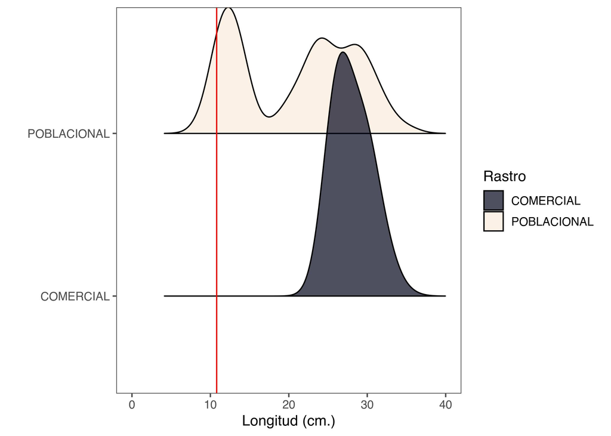

```r
s2016 <- ggplot(size2016 %>%
                  drop_na(sizeE),
               aes(x=sizeE,
                   y = as.factor(rastro),
                  fill= as.factor(rastro)))+
  geom_density_ridges2(stat = "density_ridges",
                       position = "points_sina",
                      scale = 1.5,
                      alpha=0.7)+
  # geom_density_ridges2(stat = "binline",
  #                      position = "points_sina",
  #                     scale = 1.5,
  #                     alpha=0.7)+
  #facet_wrap(rastro~., ncol=4) +
  geom_vline(xintercept = 10.8, color = "red")+
  scale_fill_viridis_d(option="F",
                       name="Rastro")+
  theme(axis.text.x = element_text(angle = 90, hjust = 1))+
  theme_few()+
  xlab("Longitud (cm.)")+
  ylab("")+
  xlim(0,40)
#scale_x_discrete((limits = rev(levels(talla2021$ANO_ARR))))+
s2016
```

## Datos 2017-2020

estos datos tienen otros campos pero seguiremos la logica de los campos previos, es decir;

[1] “sizeE” “Beach” “Sampling.point”  
[4] “rastro” “CAT” “Categoria”  
[7] “size” “ID_codificado_muestreo” “Date”  
[10] “DIA” “MES” “ANO”

```r
# Datos 2020 size and dens and abundance join
size2017 <- read.csv2(here("Data",
                           "Anterior a 2020",
                           "data_ieo_2017_def.csv"),
                      dec=".") %>%
  select(c(22, 3, 4, 12, 19, 20, 21, 2)) %>%
   mutate(
    ID_codificado_muestreo=NA
    )%>%
  rename(sizeE=SizeE,
         size=Size)


size2018 <- read.csv2(here("Data",
                           "Anterior a 2020",
                           "data_ieo_2018_def.csv"),
                      dec=".") %>%
  select(c(22, 3, 4, 12, 19, 20, 21, 2)) %>%
   mutate(
    ID_codificado_muestreo=NA
    ) %>%
  rename(sizeE=SizeE,
         size=Size)
size2019 <- read.csv2(here("Data",
                           "Anterior a 2020",
                           "data_ieo_2019_def.csv"),
                      dec=".") %>%
  select(c(22, 3, 4, 12, 19, 20, 21, 2)) %>%
   mutate(
    ID_codificado_muestreo=NA
    ) %>%
  rename(sizeE=SizeE,
         size=Size)


size2020 <- read.csv2(here("Data",
                           "Anterior a 2020",
                           "data_ieo_2020_def.csv"),
                      dec=".") %>%
  select(c(22, 3, 4, 12, 19, 20, 21, 2)) %>%
   mutate(
    ID_codificado_muestreo=NA
    ) %>%
  rename(sizeE=SizeE,
         size=Size)
```

Same names. Could merge the DF

```r
size_17_20 <- rbind(size2017,
                    size2018,
                    size2019,
                    size2020)
size_17_20$Date <- dmy(size_17_20$Date)
```

Comprubo la estructura

```r
summary(size_17_20)
```

```
##      sizeE           Beach           Sampling.point        rastro
##  Min.   :  2.00   Length:62083       Length:62083       Length:62083
##  1st Qu.: 16.00   Class :character   Class :character   Class :character
##  Median : 22.00   Mode  :character   Mode  :character   Mode  :character
##  Mean   : 20.65
##  3rd Qu.: 26.00
##  Max.   :102.00
##       CAT         Categoria              size            Date
##  Min.   :1.000   Length:62083       Min.   : 2.83   Min.   :2017-07-13
##  1st Qu.:1.000   Class :character   1st Qu.:16.20   1st Qu.:2018-05-14
##  Median :2.000   Mode  :character   Median :22.38   Median :2019-01-10
##  Mean   :1.528                      Mean   :21.12   Mean   :2019-02-15
##  3rd Qu.:2.000                      3rd Qu.:26.23   3rd Qu.:2019-11-14
##  Max.   :2.000                      Max.   :79.50   Max.   :2020-12-17
##  ID_codificado_muestreo
##  Mode:logical
##  NA's:62083
##
##
##
##
```

Change `Date` columns from `character`to `Date` format

```r
# separo los meses , dias y años
# Separar en columnas de día, mes y año

size_17_20<- size_17_20 %>%
  mutate(
    DIA = day(Date),
    MES = month(Date),
    ANO = year(Date)
  )
unique(size_17_20$ANO)
```

```
## [1] 2017 2018 2019 2020
```

a qui tengo diferencias con los nombres. Verificar cuando se junten todos los años

## Data 2020-2024

```r
size2021 <- read_excel(here("Data",
                            "Posterior 2020",
                            "Data_size_Coquina_2021.xlsx"),
                       sheet = "Coquina_donax") %>%
  select(-c(1, 10, 11))
size2022 <- read_excel(here("Data",
                            "Posterior 2020",
                            "Data_size_Coquina_2022.xlsx"),
                       sheet = "Coquina_donax") %>%
  select(-c(1, 2))
size2023 <- read_excel(here("Data",
                            "Posterior 2020",
                            "Data_size_Coquina_2023.xlsx"),
                       sheet = "Coquina_Donax") %>%
  select(-c(1, 2))

size2024 <- read_excel(here("Data",
                            "Posterior 2020",
                            "Data_size_Coquina_2024.xlsx"),
                       sheet = "Coquina_Donax") %>%
  select(-c(1, 2))
```

Now, we handling data 2021-2023. Same columns data 2017-2020

```r
size_21_24 <- rbind(size2021,
                    size2022,
                    size2023,
                    size2024)
```

Separate `Date` column

```r
size_21_24<- size_21_24 %>%
  mutate(
    DIA = day(Date),
    MES = month(Date),
    ANO = year(Date)
  )
unique(size_21_24$rastro)
```

```
## [1] "POBLACIONAL" "COMERCIAL"
```

```r
# join data
sizeall <- rbind(size2013,
                 size14_15,
                 size2016,
                 size_17_20,
                 size_21_24)
```

```r
dim(sizeall)
```

```
## [1] 213384     12
```

```r
table(sizeall$ANO)
```

```
##
##  2013  2014  2015  2016  2017  2018  2019  2020  2021  2022  2023  2024
##  6179 71147 22972   386 10121 20418 18109 13435 21971 17426  9036  1957
```

```r
table(sizeall$Beach)
```

```
##
##       Donana      Donana  Donana_norte   Donana_sur       Huelva  Isla_Canela
##       105673          285        25082        15313        40841        14435
##      La_Bota       LaBota     Malandar Matalascanas      Mazagon
##         3043         1266            7          382          265
```

```r
table(sizeall$Sampling.point)
```

```
##
##     1    10    11    12    13     2     3     4    4R     5     6     7     8
## 12221 35089 15306   265     7 32160 11911 49278   221  3544 27182  9813  5182
##     9     M
##  4310   560
```

```r
table(sizeall$rastro)
```

```
##
##     COMERCIAL    COMERCIAL  COMERCIAL NEW   POBLACIONAL  POBLACIONAL
##         54145            16           873        158311            39
```

Rename values

```r
sizeall2 <- sizeall %>%
  drop_na(rastro) %>%
  mutate(rastro = str_replace_all(rastro, " ", ""),
         rastro = str_replace_all(rastro, "COMERCIALNEW", "COMERCIAL"),
         Beach = str_replace_all(Beach, "Donana", "Donaña"),
         Beach = str_replace_all(Beach, " ", ""),
         Beach = str_replace_all(Beach, "Matalascanas", "Matalascañas")) %>%
  mutate(MES = case_when(
    MES == 1 ~ "January",
    MES == 2 ~ "February",
    MES == 3 ~ "March",
    MES == 4 ~ "April",
    MES == 5 ~ "May",
    MES == 6 ~ "June",
    MES == 7 ~ "July",
    MES == 8 ~ "August",
    MES == 9 ~ "September",
    MES == 10 ~ "October",
    MES == 11 ~ "November",
    MES == 12 ~ "December")) %>%
  mutate(MES = factor(MES, levels = c("January",
                                          "February",
                                          "March",
                                          "April",
                                          "May",
                                          "June",
                                          "July",
                                          "August",
                                          "September",
                                          "October",
                                          "November",
                                          "December")))

unique(sizeall2$Beach)
```

```
##  [1] NA             "Donaña"       "Huelva"       "La_Bota"      "Isla_Canela"
##  [6] "Mazagon"      "Malandar"     "Donaña_sur"   "Donaña_norte" "LaBota"
## [11] "Matalascañas"
```

```r
unique(sizeall2$rastro)
```

```
## [1] "POBLACIONAL" "COMERCIAL"
```

```r
unique(sizeall2$MES)
```

```
##  [1] January   March     May       September October   December  <NA>
##  [8] April     June      August    November  February  July
## 12 Levels: January February March April May June July August ... December
```

```r
table(sizeall2$ANO, sizeall2$rastro)
```

```
##
##        COMERCIAL POBLACIONAL
##   2013      2255        3924
##   2014     16960       54187
##   2015       956       22016
##   2016       142         244
##   2017      3529        6592
##   2018      5330       15088
##   2019      6136       11973
##   2020      3596        9839
##   2021      7124       14847
##   2022      5732       11694
##   2023      2627        6409
##   2024       646        1311
```

## Save data

```r
saveRDS(sizeall2, "tallas_13_24.RData")
sizeall2<- readRDS("~/IEO/DATA/EDA_Donux_truculus_2023/tallas13_24.RDS")
```

some plots

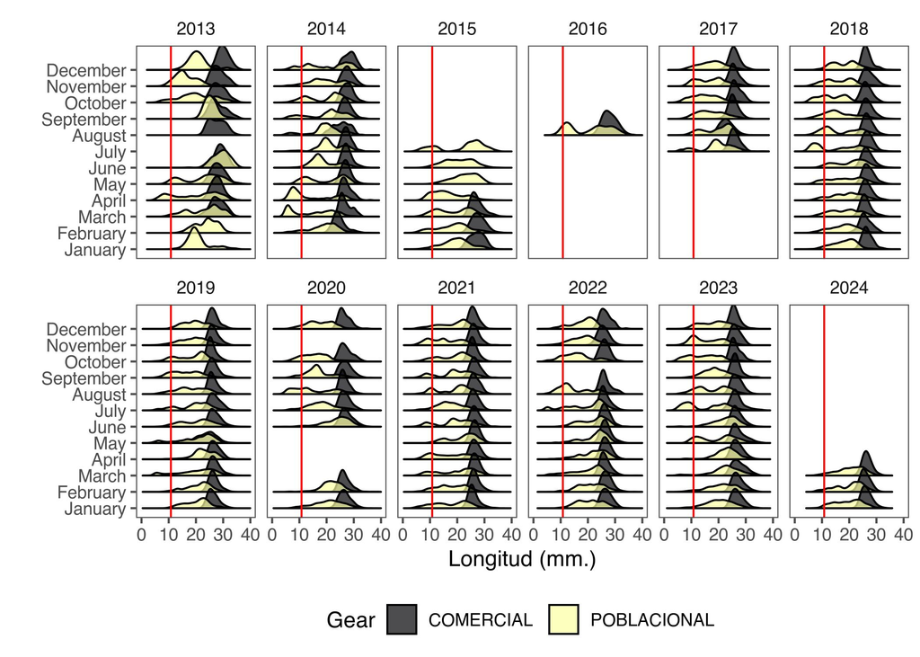

```r
nall <- ggplot(sizeall2 %>%
                 drop_na(sizeE,
                         MES),
               aes(x=sizeE,
                   y = MES,
                  fill= as.factor(rastro)))+
  # geom_density_ridges(stat = "densit",
  #                     bins = 50,
  #                     scale = 1.2,
  #                     alpha=0.7)+
   geom_density_ridges2(stat = "density_ridges",
                       position = "points_sina",
                      scale = 1.5,
                      alpha=0.7)+
  facet_wrap(.~ANO, ncol=6) +
  geom_vline(xintercept = 10.8, color = "red")+
  scale_fill_viridis_d(option="B",
                       name="Gear")+
  theme(axis.text.x = element_text(angle = 90, hjust = 1))+
  theme_few()+
  theme(legend.position = "bottom")+
  xlab("Longitud (mm.)")+
  ylab("")+
  xlim(0,40)
#scale_x_discrete((limits = rev(levels(talla2021$ANO_ARR))))+
nall
```

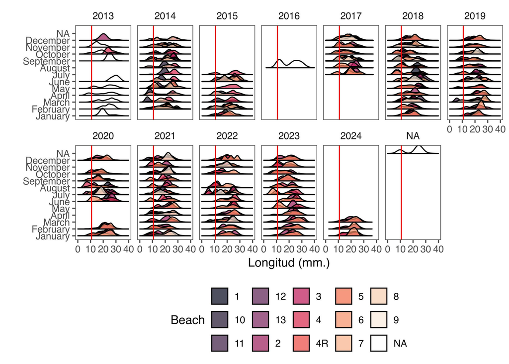

```r
nallbeach <- ggplot(sizeall2%>%
                      filter(rastro!="COMERCIAL"),
               aes(x=sizeE,
                   y = as.factor(MES),
                  fill= as.factor(Sampling.point)))+
  geom_density_ridges2(stat = "density_ridges",
                       position = "points_sina",
                      scale = 1.2,
                      alpha=0.7)+
  facet_wrap(.~ANO, ncol=7) +
  geom_vline(xintercept = 10.8, color = "red")+
  scale_fill_viridis_d(option="F",
                       name="Beach")+
  theme(axis.text.x = element_text(angle = 90, hjust = 1))+
  theme_few()+
  theme(legend.position = "bottom")+
  xlab("Longitud (mm.)")+
  ylab("")+
  xlim(0,40)
#scale_x_discrete((limits = rev(levels(talla2021$ANO_ARR))))+
nallbeach
```

just Poblacional sample

```r
pobeach <- ggplot(sizeall2 %>%
                      filter(rastro!="COMERCIAL"),
               aes(x=sizeE,
                   y = as.factor(MES),
                  fill= as.factor(Sampling.point)))+
  geom_density_ridges(stat = "binline",
                      bins = 10,
                      scale = 1.2,
                      alpha=0.7)+
  facet_wrap(.~ANO, ncol=7) +
  geom_vline(xintercept = 10.8, color = "red")+
  scale_fill_viridis_d(option="G",
                       name="Beach")+
  theme(axis.text.x = element_text(angle = 90, hjust = 1))+
  theme_few()+
  theme(legend.position = "bottom")+
  xlab("Longitud (mm.)")+
  ylab("")+
  xlim(0,40)
#scale_x_discrete((limits = rev(levels(talla2021$ANO_ARR))))+
pobeach
```

[output not shown]